# 演習の模範解答

プログラミング演習Ⅰ

佐藤 秀保

sato0035@toyo.jp

## 第12回問題

食堂では，客ごとに使用する金額にはそこまで差がないと考えられる．

そのため，「総売上が高い日であっても客単価には大差なく，単に客数が多いことが総売上を押し上げる要因だ」と仮説を立てた．

（つづく）

### 方針

- 「客単価」変数（=「総売上」÷「客数」）を作成し，
- ざっくりと総売上のレベルをわけるための
  - 「総売上」がその平均値の1.1倍以上なら3，
  - 平均値の1.1倍未満かつ平均値以上なら2，
  - 平均値未満かつ平均値の0.9倍以上なら1，
  - それ以外なら0の「総売上階級」変数を作成し，

（つづく）

- その後「総売上階級」別に「客単価」と「客数」の平均を計算し，
- 「総売上階級」の値の昇順に並び替えよ．

ただし，平均の計算にあたっては欠損値を除外し，またコードを書く際にはパイプ演算子を有効に活用すること．

書き出しのヒント

```r
df_ensyuu <- df %>%
```

総売上は客単価・客数のどちらが重要か？

### 解答例

```r
df_ensyuu <- df %>%
  filter(!is.na(総売上)) %>%
  mutate(客単価 = 総売上 / 客数) %>%
  mutate(総売上階級 = case_when(
    総売上 >= 1.1*mean(総売上) ~ 3,
    総売上 >= mean(総売上) ~ 2,
    総売上 >= 0.9*mean(総売上) ~ 1,
    TRUE ~ 0)
    ) %>%
  summarise(客単価平均 = mean(客単価),
            客数平均 = mean(客数),
            .by = "総売上階級"
            ) %>%
  arrange(総売上階級)

#客数の欠損行も削除しておくべきだが，今回は総売り上げが欠損していれば客数も欠損していることを知っているので省略
```

## **第11回問題**

`df`のデータを用いて，「客数」の月曜日の平均値と「客数」の火曜日の平均値をそれぞれアトミックベクトルとして抽出し，その値を比較せよ．

### 方針

1. `filter`で「客数」の`NA`を削除
2. `mutate`で「曜日」の列を追加
3. `filter`で「Monday」を抽出
4. `summarise`で平均を計算したデータフレームをゲット
5. 4をアトミックベクトルとして抽出

※火曜日も上の方法と同様

ただし，3で月曜日を`filter`するときは，`filter(データフレーム名, 曜日 == "Monday")`のように==を使うことでその曜日に等しいという条件に合致する場合の行を判定し抽出できることに注意する．

### 解答例

```r
#tidyverseパッケージは読込済とする
#syokudo_data2のエクセルは読込済とする

#客数の月曜日平均
df1 <- filter(df, 客数 > 0)
df2 <- mutate(df1, 曜日 = weekdays(日付))
df3 <- filter(df2, 曜日 == "Monday")
df4 <- summarise(df3, 客数平均 = mean(客数))
mean_monday <- df4$客数平均

#客数の火曜日平均
df5 <- filter(df2, 曜日 == "Tuesday")
df6 <- summarise(df5, 客数平均 = mean(客数))
mean_tuesday <- df6$客数平均

#客数平均の比較例
mean_monday / mean_tuesday
```

## 第10回問題

`df`から「日付」，「総売上」，「販売点数」，「客数」，の列のみを抽出し，`df_ensyuu`という名前にデータフレームとして保存せよ．

### 解答例

```r
#tidyverseパッケージは読込済とする
#syokudo_data1のエクセルは読込済とする

df_ensyuu <- select(df,
                    日付, 総売上, 販売点数, 客数)
```

## 第９回問題

2026年6月1日（月）～5日（金）までの朝霞キャンパス食堂の売上額sales，客数n_customers，客単価price_customersデータが日付順にそれぞれ以下のようにアトミックベクトルとして保存されている．ただし，6月3日（水）は台風のためデータはなし．

```r
sales <- c(199530, 181070, 157430, 175390)
n_customers <- c(328, 298, 248, 279)
price_customers <- sales / n_customers
```

1. これらを１つのデータフレームとして保存せよ．
2. アクセッサーを用いて客単価の列を抽出せよ．
3. 火曜日の客単価のみを抽出せよ．

### 解答例

```r
#問題文のコードは実行済みとする

#データフレームに保存
df <- data.frame(sales, n_customers, price_customers )
#客単価の列抽出
df$price_customers
#火曜日の客単価のみ抽出(2コ目が火曜日であることは既知)
df$price_customers[2]
```

## 第８回問題１

３つの企業についてそれぞれ，①企業名，➁企業の利潤，③食品企業か否か，のデータがアトミックベクトルとして保存されている．

```r
firm_name <- c("企業A", "企業B", "企業C")
profit <- c(100, 200, 500)
food_firm <- c(T, F, T)
```

1. 企業名について，食品企業のもののみをアトミックベクトルとして抽出せよ
2. 利潤について，食品企業のもののみをアトミックベクトルとして抽出せよ

### 解答例１

```r
#問題文のコードは実行済みとする

#食品企業の企業名をアトミックベクトルで抽出
firm_name[food_firm]
#食品企業の利潤をアトミックベクトルで抽出
profit[food_firm]
```

## 第８回問題２

以下のコードを実行した場合，何が返るか予想せよ．

```r
example1 <- list(TRUE, 2.4, list(10, c(100, 1000)))
example1[[3]][[2]][2]
```

### 解答例２

example1[[3]]は，list(10, c(100, 1000))を意味し，

example1[[3]][[2]]は，c(100, 1000)を意味し，

example1[[3]][[2]][2]は，1000を意味する．

∴アトミックベクトルで1000が返る．

## 第７回問題

10人の出身都道府県は以下のとおりである．

東京都，沖縄県，大阪府，東京都，東京都，

北海道，福岡県，大阪府，青森県，福岡県

それぞれの都道府県を横軸，該当する都道府県の人数を縦軸とした棒グラフを作成せよ．

ただし，横軸の順番は「[全国地方公共団体コード](https://news.mynavi.jp/article/20220715-2399569/)」の昇順とする．

### 解答例

```r
pref <- c("東京都",
          "沖縄県",
          "大阪府",
          "東京都",
          "東京都",
          "北海道",
          "福岡県",
          "大阪府",
          "青森県",
          "福岡県")
pref_factor <- factor(pref,
                      levels = c("北海道",
                                 "青森県",
                                 "東京都",
                                 "大阪府",
                                 "福岡県",
                                 "沖縄県")
                      )
counts_pref <- table(pref_factor)
barplot(counts_pref)
```

## 第６回問題1

[JAタウン](https://www.ja-town.com/shop/f/f3020/)では産地直送でお米の販売を行っている．

現在，5kgの精米について，「栃木県産とちほのか」，「福井県産いちほまれ」，「滋賀県産みずかがみ」の価格はそれぞれ，6,310円，5,800円，5,100円である．

価格データを，名前を付した長さ３のnumericのアトミックベクトルrice_pricesとして保存せよ．ただし，名前はそれぞれ上記の産地と銘柄名の組み合わせとする．

### 解答例１

```r
rice_prices <- c(栃木県産とちほのか = 6310,
                 福井県産いちほまれ = 5800,
                 滋賀県産みずかがみ = 5100)

#別解1
meigara <- c("栃木県産とちほのか",
             "福井県産いちほまれ",
             "滋賀県産みずかがみ")
rice_prices <- c(6310, 5800, 5100)
names(rice_prices) <- meigara

#別解2
meigara <- c("栃木県産とちほのか",
             "福井県産いちほまれ",
             "滋賀県産みずかがみ")
kakaku <- c(6310, 5800, 5100)
rice_prices <- setNames(kakaku, meigara)
```

## 第６回問題２

2026年4月の学食における定食の売上額は「鶏のから揚げ定食」が最も高く，次に「シン・チキン南蛮定食」，その次に「半熟オムライス デミグラスソース」であり，順に537080円, 392840円, 231840円であった．

販売数でみると，「鶏のから揚げ定食」が926, 「シン・チキン南蛮定食」が644, 「半熟オムライス デミグラスソース」が368だった．

行名を商品名，列名を「売上額」，「販売数」とした3行2列の行列データgakusyokuを作成せよ．ただし，行における商品の順番は問わず自由とする．

### 方針

アトミックベクトルにデータを格納し，行列に変換し，行名・列名をつける．

完成図：

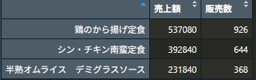

### 解答例２

```r
mat <- c(537080, 392840, 231840,
         926, 644, 368)
dim(mat) <- c(3, 2)
colnames(mat) <- c("売上額", "販売数")
rownames(mat) <- c("鶏のから揚げ定食",
                   "シン・チキン南蛮定食",
                   "半熟オムライス　デミグラスソース")

#別解
vec <- c(537080, 392840, 231840,
         926, 644, 368)
mat <- matrix(vec, nrow = 3, ncol = 2)
colnames(mat) <- c("売上額", "販売数")
rownames(mat) <- c("鶏のから揚げ定食",
                   "シン・チキン南蛮定食",
                   "半熟オムライス　デミグラスソース")
```

## 第５回問題

以下の４つの市販のチョコレートについて，示されている順番に「商品名」をcharacterとしてまとめた長さ４のアトミックベクトルchoco_namesと，「カロリー」をnumericとしてまとめた長さ４のアトミックベクトルcalsをそれぞれ生成し，それらを長さ２のリストchoco_lisとして保存せよ．ただし，カロリーはインターネットで検索し調べること．

1. 明治ミルクチョコレート 50g
2. 明治ブラックチョコレート 50g
3. ロッテ ガーナミルクチョコレート 50g
4. ロッテ ガーナブラック 50g

### 解答例

```r
choco_names <- c("明治ミルクチョコレート 50g",
                 "明治ブラックチョコレート 50g",
                 "ロッテ ガーナミルクチョコレート 50g",
                 "ロッテ ガーナブラック 50g")
cals <- c(283, 288, 278, 287)
choco_lis <- list(choco_names, cals)
```

## 第４回問題１

- A, B, Cの３人の学生について
  - 身長：1.72m, 1.52m, 1.68m
  - 体重：66kg, 57kg, 65kg
- BMIの定義式は
  - 体重(kg)÷(身長(m)の2乗)
- 身長と体重をそれぞれアトミックベクトルとしてheight，weightという名称のオブジェクトにそれぞれ代入せよ
- 各学生のBMIの値を入れたアトミックベクトルを，BMIという名称のオブジェクトに代入せよ

### 解答例１

```r
height <- c(1.72, 1.52, 1.68)
weight <- c(66, 57, 65)
BMI <- weight/height^2
```

## 第４回問題２

**以下のアトミックベクトルの型を予想せよ**

- c(1.1, FALSE)
- c(“a”, 1.1)
- c(“a”, 1.1, TRUE, 4L)
- c(2L, 2L) * c(T, F)

### 解答例２

アトミックベクトルでは同一の型へ「型の強制変換」が生じ，柔軟性の高い型へと統一される．柔軟性は，

論理（logi） < 整数（int） < 倍精度小数点（num） < 文字（chr）

なので，答えは順にnum, chr, chr, intとなる．最後の問いは，計算時にT, Fが1L, 0Lとより柔軟性の高い整数へ変換され整数同士の計算となる．

## 第３回問題

- 黄金比（美しいとされる比率で約1.618）を計算
  - パルテノン神殿正面の「横：高さ」
  - 『ウィトルウィウス的人体図』の「顔の長さ：幅」

    …と言われているが信ぴょう性は低い
- 定義式：$\frac{1 + \sqrt{5}}{2}$
- スクリプトで上式を書き実行し，約1.618が返るか確認

※ ヒント：分子を括弧でくくってから割り算すること

### 解答例

```r
(1 + sqrt(5))/2
```